# The search for allopatric speciation in the gut microbial communities of Tanganyikan cichlids

## An adventure in fish poo.

*Russell Neches*

# Background : Rachel Whitaker's hotspring biogeography

The inspiration for this whole project, and still one of the most exciting papers I've ever read...

[figure not shown]

Biogeography

[figure not shown]

Biogeography

[figure not shown]

Biogeography

# More background : Carl Huffaker's oranges

[figure not shown]

Oranges

# Community structure matters

[figure not shown]

Oranges

[figure not shown]

Oranges

# Ecological stability depends on an environment with some texture

[figure not shown]

Oranges

# A microbial community with some cool stucture

I spent a lot of time trying to think of ways to re-create Rachel Whitaker's hotsprings system or Carl Huffacker's oranges.

But then I remembered Jonathan's *other* advice...

[figure not shown]

All the things

[figure not shown]

All the things

```
WARNING: pylab import has clobbered these variables: ['f', 'table']
`%matplotlib` prevents importing * from pylab and numpy
```

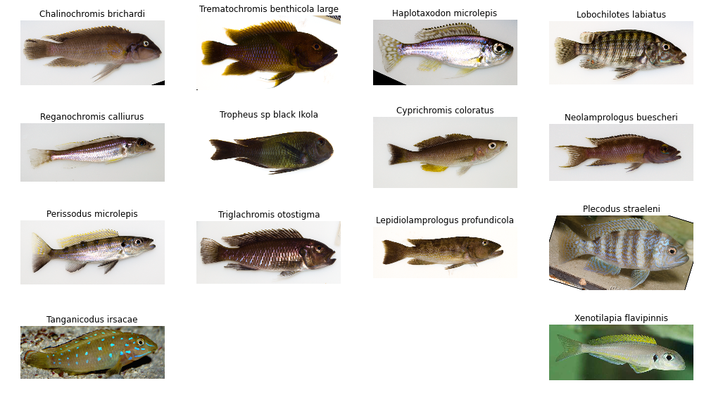

```python
%pylab inline

from IPython.display import display, Image
import os
import matplotlib.image as mpimg
import matplotlib.pyplot as plt

figure(figsize=(14, 8))

for root, _, files in os.walk('host_phenotypes') :
    for n,file in enumerate(files) :
        i =  mpimg.imread('host_phenotypes/' + file )
        subplot(4,4,n)
        plt.imshow(i)
        title(file.replace('_',' ').replace('.png',''))
        plt.axis('off')

plt.tight_layout()
```

```python
from os import chdir, mkdir
from os.path import join
#the following are only available in the current development branch of IPython
from IPython.display import FileLinks, FileLink

mapping_file = "fishpoo_map.tsv"

# concatinated, de-multiplexed reads
demuldata = 'demul/qiime_ready/fishpoo.fasta'

# output directory
outdir = 'fishpoo_open97'

otu_base = "/home/russell/gg_13_8_otus/"

reference_seqs_99 = join(otu_base,"rep_set/99_otus.fasta")
reference_tree_99 = join(otu_base,"trees/99_otus.tree")
reference_tax_99 = join(otu_base,"taxonomy/99_otu_taxonomy.txt")
reference_seqs_97 = join(otu_base,"rep_set/97_otus.fasta")
reference_tree_97 = join(otu_base,"trees/97_otus.tree")
reference_tax_97 = join(otu_base,"taxonomy/97_otu_taxonomy.txt")

pynast_ref_alignment = "/home/russell/qiime/lib/python2.7/site-packages/qiime_test_data/identify_chimeric_seqs/ref_seq_set_aligned.fasta"
```

# Now, you too can use Guillaume de-multiplexing script!

There's a README and everything.

```python
# This demultiplexing tool comes from Guillaume Jospin's scripts, which
# are available here :
#    https://github.com/gjospin/scripts
#
# This script requires Trimmomatic and flash. The flash binary can be
# installed anywhere, as long as it is in $PATH.
#
#    http://ccb.jhu.edu/software/FLASH/
#
# The path to the Trimmomatic jar file has to be passed to the script
# directly using the --trim-tool option, and the jar file MUST be
# nammed 'trimmomatic.jar'. I did this with a simlink, like so :
#
# http://www.usadellab.org/cms/?page=trimmomatic
# unzip Trimmomatic-0.32.zip
# cd Trimmomatic-0.32
# ln -s trimmomatic-0.32.jar trimmomatic.jar

!perl raw/Demul_trim_prep.pl \
--trim-file ../barcodes/adapter_all_16s.txt \
--trim-tool /home/russell/pkg/Trimmomatic-0.32/ \
--read-len 300 \
--frag-len 253 \
--reverse \
raw fishpoo_map.tsv demul fishpoo &> demul.log

# lump all the files together again
!cat demul/qiime_ready/fishpoo.M.*.faa > $demuldata

# Adjsut the sequence orientation so the reast of QIIME will work

!adjust_seq_orientation.py -i $demuldata -o fishpoo.fasta
```

# Not everything is working yet...

QIIME can't find ChimeraSlayer yet. I haven't summoned the energy to fix this yet.

```python
!identify_chimeric_seqs.py \
-m ChimeraSlayer \
-i fishpoo_open_reference_otus/pynast_aligned_seqs/rep_set_aligned_pfiltered.fasta \
-a /home/russell/gg_13_8_otus/rep_set_aligned/97_otus.fasta \
-o fishpoo_open_reference_otus/chimeras.txt
```

# OTU picking is much faster when you don't use your laptop

Picking OTU completes in about 20-30 minuts on edhar's 16 CPUs. This will be *much* faster after we get a new lab server...

```python
!pick_open_reference_otus.py \
-r $reference_seqs_97 \
-i fishpoo.fasta \
-o $outdir \
-f -a -O 16
```

# Bud sadly, not everything works in parallel

Building trees is always slow and painful. In this case, about 40 minutes.

```python
!make_phylogeny.py -i $outdir/pynast_aligned_seqs/rep_set_aligned.fasta
```

# QIIME 1.9.0 changed the BIOM format again

New BIOM tables are no longer JSON files, but are instead HDF5.

```python
##
## Wrangle the BIOM tables.
##

# add our metadata

!biom add-metadata \
-i $outdir/otu_table_mc2_w_tax.biom \
-m $mapping_file \
-o $outdir/fishpoo_all.biom

# Phase I

!filter_samples_from_otu_table.py \
-i $outdir/fishpoo_all.biom \
-o $outdir/fishpoo_phase1_unfiltered.biom \
-m $mapping_file \
-s "Experiment:Phase I"

# remove OTUs with zero counts
!filter_otus_from_otu_table.py \
-i $outdir/fishpoo_phase1_unfiltered.biom \
-o $outdir/fishpoo_phase1.biom \
-n 1

# convert to JSON format for phyloseq
!biom convert \
-i $outdir/fishpoo_phase1.biom \
-o $outdir/fishpoo_phase1.json.biom \
--table-type="OTU table" --to-json

!biom summarize-table \
-i $outdir/fishpoo_phase1.biom \
-o $outdir/fishpoo_phase1.summary

# Phase II

!filter_samples_from_otu_table.py \
-i $outdir/fishpoo_all.biom \
-o $outdir/fishpoo_phase2_unfiltered.biom \
-m $mapping_file \
-s "Experiment:Phase II"

# remove OTUs with zero counts
!filter_otus_from_otu_table.py \
-i $outdir/fishpoo_phase2_unfiltered.biom \
-o $outdir/fishpoo_phase2.biom \
-n 1

# convert to JSON format for phyloseq
!biom convert \
-i $outdir/fishpoo_phase2.biom \
-o $outdir/fishpoo_phase2.json.biom \
--table-type="OTU table" --to-json

!biom summarize-table \
-i $outdir/fishpoo_phase2.biom \
-o $outdir/fishpoo_phase2.summary

# Dilution

!filter_samples_from_otu_table.py \
-i $outdir/fishpoo_all.biom \
-o $outdir/fishpoo_dilution_unfiltered.biom \
-m $mapping_file \
-s "Experiment:Dilution"

# remove OTUs with zero counts
!filter_otus_from_otu_table.py \
-i $outdir/fishpoo_dilution_unfiltered.biom \
-o $outdir/fishpoo_dilution.biom \
-n 1

# convert to JSON format for phyloseq
!biom convert \
-i $outdir/fishpoo_dilution.biom \
-o $outdir/fishpoo_dilution.json.biom \
--table-type="OTU table" --to-json

!biom summarize-table \
-i $outdir/fishpoo_dilution.biom \
-o $outdir/fishpoo_dilution.summary
```

# Core diversity analysis...

Let's look at some [hideous plots](http://edhar.genomecenter.ucdavis.edu/~russell/fishpoo/fishpoo_open97/core_diversity_phase1/).

```python
# run core diversity for each experiment

!core_diversity_analyses.py \
-i $outdir/fishpoo_phase1.biom \
-o $outdir/core_diversity_phase1 \
-m $mapping_file \
-e 26221 \
-t $outdir/rep_set.tre

!core_diversity_analyses.py \
-i $outdir/fishpoo_phase2.biom \
-o $outdir/core_diversity_phase2 \
-m $mapping_file \
-e 26221 \
-t $outdir/rep_set.tre

!core_diversity_analyses.py \
-i $outdir/fishpoo_dilution.biom \
-o $outdir/core_diversity_dilution \
-m $mapping_file \
-e 26221 \
-t $outdir/rep_set.tre
```

# But of course, we would probably like to do some real statistics

And until pandas catches up, that means R.

```python
%load_ext rmagic
```

# Here's how to load data into phyloseq

Things discovered by trial and error : * Phyloseq doesn't support HDF5 BIOM tables yet * It wants the tree you built after open reference clustering * It wants the **new_refseq.fna** file

```python
%%R
library("phyloseq")
print( packageVersion("phyloseq") )
library("ggplot2")
print( packageVersion("ggplot2") )
library("biom")
print( packageVersion("biom") )

fishpoo_phase1 <- import_biom("fishpoo_open97/fishpoo_phase1.json.biom",
                              "fishpoo_open97/rep_set.tre",
                              "fishpoo_open97/new_refseqs.fna",
                              parseFunction = parse_taxonomy_greengenes)
```

```
[1] ‘1.9.15’
[1] ‘1.0.0’
[1] ‘0.3.12’
```

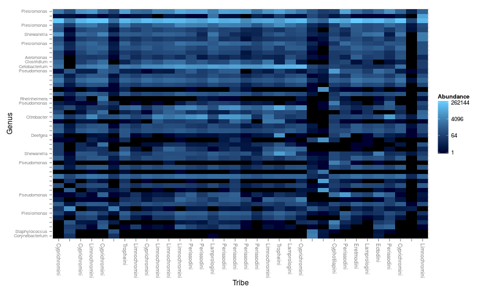

```python
%%R -w 800 -h 480 -u px
#plot_heatmap( subset_taxa( fishpoo_phase1, Phylum=="Proteobacteria") )
#plot_heatmap( subset_taxa( fishpoo_phase1, Phylum=="Firmicutes"), "MDS", "unifrac", "Host", "Family", weighted=TRUE )
plot_heatmap( prune_taxa( names(sort(taxa_sums(fishpoo_phase1),TRUE)[1:50] ), fishpoo_phase1 ),
             "MDS", "unifrac", "Tribe", "Genus", weighted=TRUE )
```

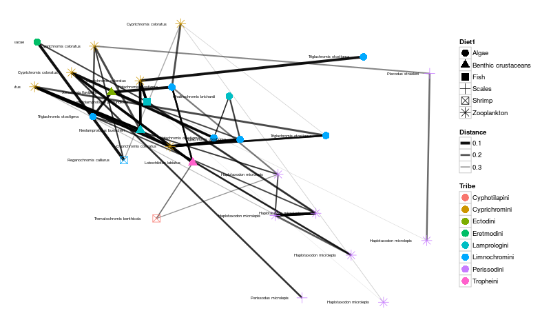

```python
%%R -w 800 -h 480 -u px
plot_net( fishpoo_phase1, maxdist = 0.4, point_label = "Host", color="Tribe", shape="Diet1")
```

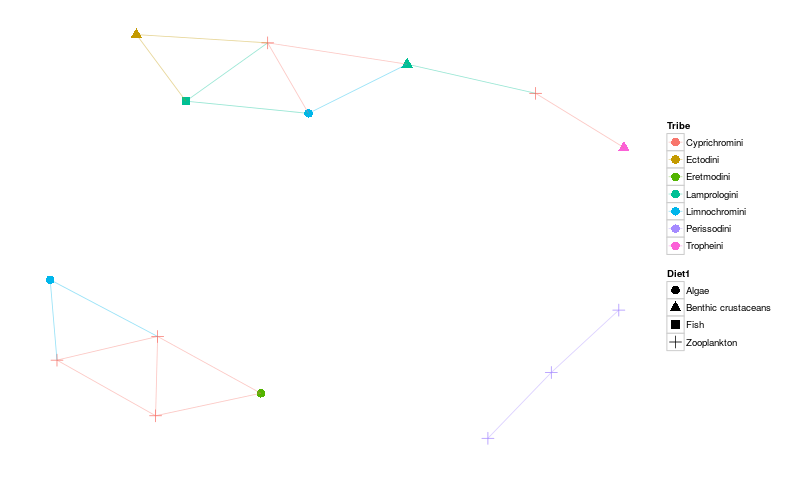

```python
%%R -w 800 -h 480 -u px
fishpoo_phase1_net <- make_network( fishpoo_phase1, max.dist=0.3, dist.fun="unifrac" )
plot_network( fishpoo_phase1_net, fishpoo_phase1, color="Tribe", shape="Diet1", line_weight=0.4, label=NULL)
```

```
... procrustes: rmse 0.01283415  max resid 0.04956053
... procrustes: rmse 0.01276356  max resid 0.05003602
... procrustes: rmse 0.0119522  max resid 0.04989746
... procrustes: rmse 0.0005316482  max resid 0.0027105
*** Solution reached

Species coordinates not found directly in ordination object. Attempting weighted average (`vegan::wascores`)
```

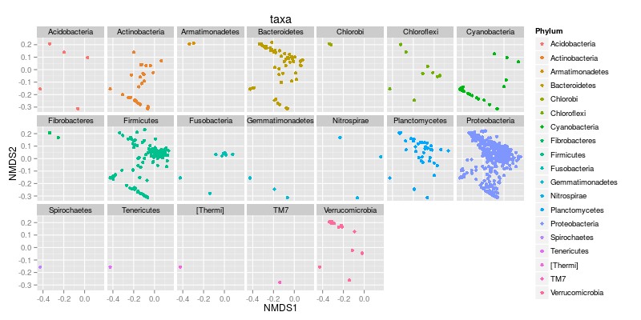

```python
%%R -w 800 -h 400 -u px
fishpoo_phase1_ord <- ordinate( fishpoo_phase1, "NMDS", "unifrac")
p1 = plot_ordination( fishpoo_phase1,
                      fishpoo_phase1_ord,
                      type = "taxa", color = "Phylum", title = "taxa")
p1 = p1 + facet_wrap(~Phylum, 3)
print(p1)
```

```
Species coordinates not found directly in ordination object. Attempting weighted average (`vegan::wascores`)
```

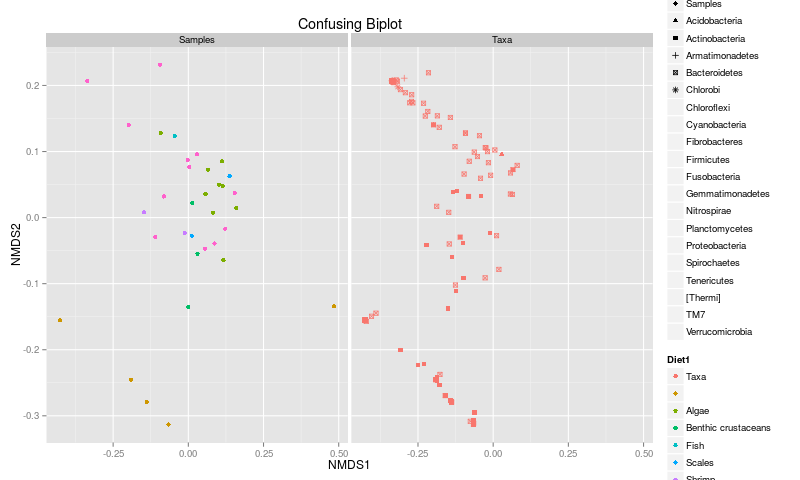

```python
%%R -w 800 -h 480 -u px
p3 = plot_ordination( fishpoo_phase1,
                      fishpoo_phase1_ord,
                      type = "split", color = "Diet1", shape = "Phylum",
                      title = "Confusing Biplot" )
print(p3)
```

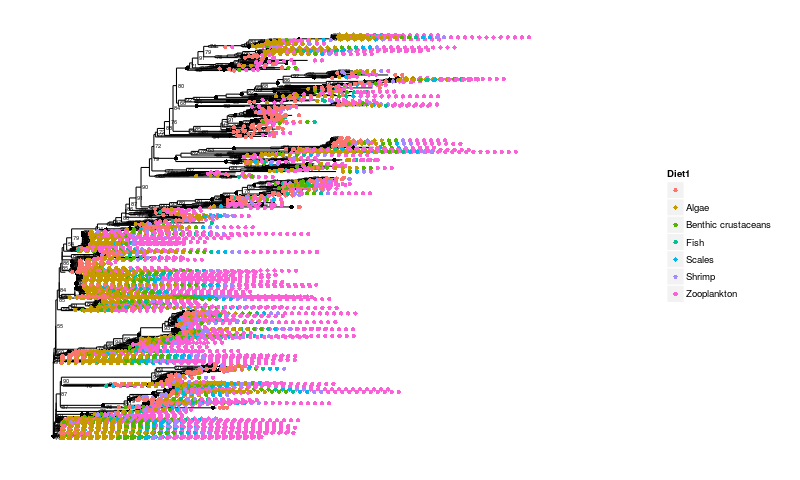

```python
%%R -w 800 -h 480 -u px
plot_tree( prune_taxa( names(sort(taxa_sums(fishpoo_phase1),TRUE)[1:1000] ),
                      fishpoo_phase1 ),
          nodelabf = nodeplotboot(), ladderize = "left", color = "Diet1" )
```

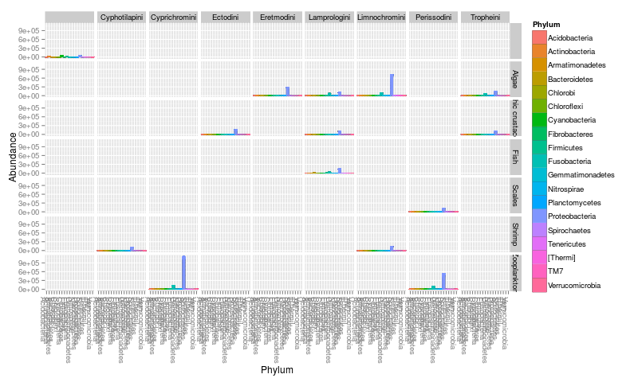

```python
%%R -w 800 -h 480 -u px
p = plot_bar( fishpoo_phase1, "Phylum", fill="Phylum", facet_grid=Diet1~Tribe )
p + geom_bar(aes(color=Phylum, fill=Phylum), stat="identity", position="stack")
```

# Sometimes, R just doesn't make any sense to me

So, I escape to python for a bit to build a table of OTU "dosages" per sample in terms of percents.

```python
%%R
write.table( otu_table(fishpoo_phase1), file="fishpoo_phase1_otus.csv", sep="," )
```

```python
import csv

colnames, rownames = [],[]
table = []
with open("fishpoo_phase1_otus.csv") as f :
    for n,row in enumerate(csv.reader(f)) :
        if n == 0 : rownames = row; continue
        colnames.append(row[0])
        table.append(map(int, row[1:]))

table = array(table)
sampleID = {}
with open("fishpoo_map.tsv") as f :
    for n,row in enumerate(csv.reader(f, delimiter='\t')) :
        if n == 0 : continue
        if not row[6] == 'Phase I' : continue
        sampleID[row[0]] = row[13]

# merge replicates, normalize OTU counts to continuously variable
# traits totalling to 100 per host
mergeddata = {}
for n,name in enumerate(rownames) :
    if not mergeddata.has_key(sampleID[name]) :
        mergeddata[sampleID[name]] = zeros(len(colnames))
    mergeddata[sampleID[name]] = map(float, table[:,n])
for key in mergeddata.keys() :
    mergeddata[key] = 100 * ( mergeddata[key] / sum(mergeddata[key]) )

f = open( 'fishpoo_phase1_otus_vs_host.csv', 'w' )
f.write(','.join(colnames) + '\n' )
for n,name in enumerate(mergeddata.keys()) :
    if name == "Food" : continue
    if name == "Charcoal_control" : continue
    if name == "Control_1" : continue
    if name == "Kit_control" : continue
    if name == "Water_control" : continue
    f.write(name + ',' + ','.join( map(str, mergeddata[name] ) ) + '\n' )
f.close()
```

```python
OTU_dosages = {}
for host in mergeddata.keys() :
    OTU_dosages[host] = sorted( zip( colnames, mergeddata[host] ), key=lambda x: x[1], reverse=True )
    print host
    for OTU, dosage in OTU_dosages[host][:3] :
        print '\t -> ' + str(OTU) + '\t : ' + str(dosage)
```

```
Haplotaxodon_microlepis
	 -> 839235	 : 38.8832761694
	 -> 828162	 : 17.9097946603
	 -> 922761	 : 16.2515041731
Xenotilapia_flavipinnis
	 -> 839235	 : 89.82721944
	 -> 278789	 : 1.81382911329
	 -> 141105	 : 1.21233137057
Plecodus_straeleni
	 -> 839235	 : 61.0975482525
	 -> 828162	 : 30.3787167449
	 -> 922761	 : 3.41575378195
Tanganicodus_irsacae
	 -> 839235	 : 95.2798889467
	 -> 804686	 : 0.667707791081
	 -> 222706	 : 0.505986465383
Reganochromis_calliurus
	 -> 839235	 : 67.4032220338
	 -> 91378	 : 20.1947254547
	 -> 836783	 : 1.93044266417
Control_1
	 -> 839235	 : 65.1612903226
	 -> 222706	 : 8.38709677419
	 -> 922761	 : 5.16129032258
Food
	 -> 1892252	 : 29.909486079
	 -> 153978	 : 24.9325960163
	 -> 3541	 : 14.9458016947
Cyprichromis_coloratus
	 -> 839235	 : 93.9935767298
	 -> 836783	 : 0.886943788065
	 -> 804686	 : 0.791676373681
Water_control
	 -> 1111294	 : 27.0350625384
	 -> 839235	 : 15.0092269838
	 -> 548999	 : 2.30674595038
Neolamprologus_buescheri
	 -> 839235	 : 94.0823343909
	 -> 836783	 : 1.1293907559
	 -> 804686	 : 0.797887497863
```

[output cut: 21 more lines]

```
	 -> 839235	 : 82.9750372124
	 -> 828162	 : 4.63141455797
	 -> 922761	 : 2.68173055806
Charcoal_control
	 -> 1111294	 : 41.2856361013
	 -> 839235	 : 12.6722722524
	 -> 1002005	 : 6.97547141649
Perissodus_microlepis
	 -> 839235	 : 36.1836025173
	 -> 922761	 : 33.4165823175
	 -> 141105	 : 21.0447564142
Lepidiolamprologus_profundicola
	 -> 839235	 : 73.5765481895
	 -> 828162	 : 16.5581458497
	 -> 922761	 : 2.04671580746
```

# Host tree

Despite having only 14 taxa, it's been surprisingly difficult to build a trustworthy phylogeny of my fish. So, I am instead using a huge published phylogeny, and pruning it to 14 taxa.

Four of my fish aren't in the published tree, so I am using sister species as stand-ins. These groups are mostly polytomies just above the genus level, so... hopefully that's OK.

```
Read 14 items
```

[figure not shown]

```python
%%R -w 800 -h 480 -u px
library(ape)

# This tree comes from here : http://datadryad.org/resource/doi:10.5061/dryad.j4802

rabosky <- read.tree("host_tree/raboskytree/Rabosky_et_al_timetree.tre")
fishnames <- scan("host_tree/raboskytree/fish_names.txt", what='character')
rabosky_trimmed <- drop.tip( rabosky, setdiff( rabosky$tip.label, fishnames ) )

rabosky_trimmed$tip.label[1]  <- "Neolamprologus_buescheri"
rabosky_trimmed$tip.label[5]  <- "Cyprichromis_coloratus"
rabosky_trimmed$tip.label[9]  <- "Reganochromis_calliurus"
rabosky_trimmed$tip.label[11] <- "Trematochromis_benthicola"

plot(rabosky)
```

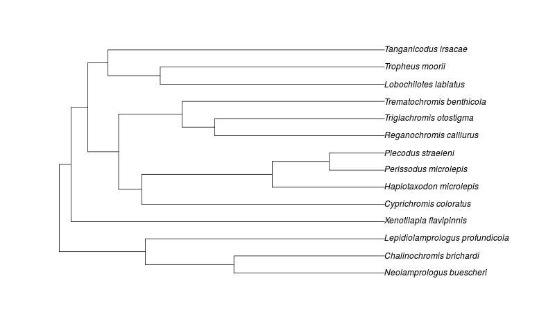

```python
%%R -w 800 -h 480 -u px
plot(rabosky_trimmed)
```

# Now, we can finally do a phylogenetic PCA

Here is what it looks like when you blindly treat the dosage of every single OTU as a continious host trait, and then map the phylogeny back onto the first and second PC...

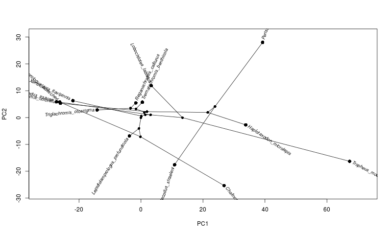

```python
%%R -w 800 -h 480 -u px
library('geiger')
library('phytools')

phase1_otus <- read.table( file="fishpoo_phase1_otus_vs_host.csv", sep=',')
td <- treedata( rabosky_trimmed, phase1_otus )

#phase1_pca <- phyl.pca( rabosky_trimmed, phase1_otus, method="BM", mode="cov")
phase1_pca <- phyl.pca( rabosky_trimmed, phase1_otus )

#plot(phase1_pca$S[,1:2])
#text(phase1_pca$S[,1:2]-0.25,rownames(phase1_pca$S), cex.lab=0.3)

phylomorphospace( rabosky_trimmed, phase1_pca$S[,1:2] )
```

# The PCA is pretty well supported, though...

```python
%%R
summary(phase1_pca)
```

[output not shown]

[output cut: 1394 more lines]

[output not shown]

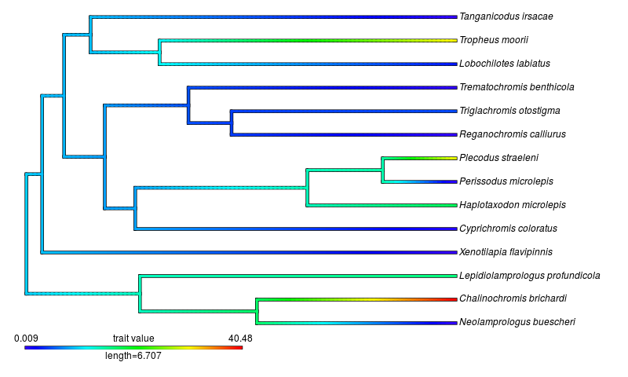

```python
%%R -w 800 -h 480 -u px

# stochastic character mapping

library("phytools")

# use make.simmap() for categorical data : http://www.inside-r.org/packages/cran/phytools/docs/make.simmap
# use contMap() for continious data : http://www.inside-r.org/node/166056

# we need this function to change the color mapping...
# code is from here : http://blog.phytools.org/2014/12/inverting-color-map-on-object-of-class.html
setMap<-function(x,...){
    if(hasArg(invert)) invert<-list(...)$invert
    else invert<-FALSE
    n<-length(x$cols)
    if(invert) x$cols<-setNames(rev(x$cols),names(x$cols))
    else x$cols[1:n]<-colorRampPalette(...)(n)
    x
}

obj <- contMap( rabosky_trimmed, as.matrix(phase1_otus)[,"X828162"], plot=FALSE )
plot(setMap(obj,invert=TRUE))
```

# Distribution of Aeromonas

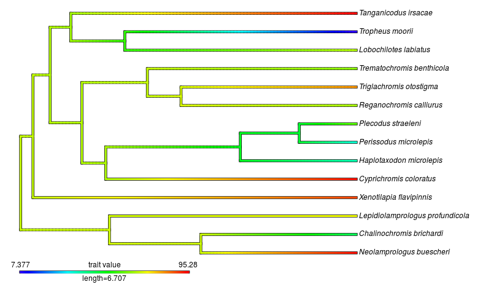

```python
%%R -w 800 -h 480 -u px
# Plot Aeromonas distrobution https://microbewiki.kenyon.edu/index.php/Aeromonas
obj <- contMap( rabosky_trimmed, as.matrix(phase1_otus)[,"X839235"], plot=FALSE )
plot(setMap(obj,invert=TRUE))
```

# What's next

The most interesting systems to study using these methods are ones where we have lots of metadata about the system itself. Those are where we can potentially gain the most powerful insights.

This poses some methodological challenges. It's easy to overconstrain the data.

# The Dueling Trees problem

[figure not shown]

Dueling Trees

# That's all for now!

The next thing I'm working on is ranking OTUs by their phylogenetic signal among their hosts...